# Answer to Homework 5 Programming Task

Langtao Chen

Update: Mar 5, 2021

```r
# Clean the environment
rm(list = ls())
```

The data file “credit-g.csv” contains a German credit dataset. The dataset contains 1000 observations (customers) of 21 variables. The response variable is “class”.

# 1. Read in the Dataset

Use read.csv() to read in the data file to create a data frame. Use “?read.csv” to learn the detail of the method. Automatically treat strings as factors (Hint: set the stringsAsFactors as TRUE).

```r
df <- read.csv('credit-g.csv', stringsAsFactors = TRUE)

str(df)
```

```
## 'data.frame':    1000 obs. of  21 variables:
##  $ checking_status       : Factor w/ 4 levels "'no checking'",..: 2 4 1 2 2 1 1 4 1 4 ...
##  $ duration              : int  6 48 12 42 24 36 24 36 12 30 ...
##  $ credit_history        : Factor w/ 5 levels "'all paid'","'critical/other existing credit'",..: 2 4 2 4 3 4 4 4 4 2 ...
##  $ purpose               : Factor w/ 10 levels "'domestic appliance'",..: 8 8 5 6 2 5 6 3 8 2 ...
##  $ credit_amount         : int  1169 5951 2096 7882 4870 9055 2835 6948 3059 5234 ...
##  $ savings_status        : Factor w/ 5 levels "'no known savings'",..: 1 2 2 2 2 1 5 2 3 2 ...
##  $ employment            : Factor w/ 5 levels "<1",">=7","1<=X<4",..: 2 3 4 4 3 3 2 3 4 5 ...
##  $ installment_commitment: int  4 2 2 2 3 2 3 2 2 4 ...
##  $ personal_status       : Factor w/ 4 levels "'female div/dep/mar'",..: 4 1 4 4 4 4 4 4 2 3 ...
##  $ other_parties         : Factor w/ 3 levels "'co applicant'",..: 3 3 3 2 3 3 3 3 3 3 ...
##  $ residence_since       : int  4 2 3 4 4 4 4 2 4 2 ...
##  $ property_magnitude    : Factor w/ 4 levels "'life insurance'",..: 3 3 3 1 2 2 1 4 3 4 ...
##  $ age                   : int  67 22 49 45 53 35 53 35 61 28 ...
##  $ other_payment_plans   : Factor w/ 3 levels "bank","none",..: 2 2 2 2 2 2 2 2 2 2 ...
##  $ housing               : Factor w/ 3 levels "'for free'","own",..: 2 2 2 1 1 1 2 3 2 2 ...
##  $ existing_credits      : int  2 1 1 1 2 1 1 1 1 2 ...
##  $ job                   : Factor w/ 4 levels "'high qualif/self emp/mgmt'",..: 4 4 3 4 4 3 4 1 3 1 ...
##  $ num_dependents        : int  1 1 2 2 2 2 1 1 1 1 ...
##  $ own_telephone         : Factor w/ 2 levels "none","yes": 2 1 1 1 1 2 1 2 1 1 ...
##  $ foreign_worker        : Factor w/ 2 levels "no","yes": 2 2 2 2 2 2 2 2 2 2 ...
##  $ class                 : Factor w/ 2 levels "bad","good": 2 1 2 2 1 2 2 2 2 1 ...
```

Calculate the number of customers who have good credit.

```r
library(dplyr)
df %>% filter(class == 'good') %>% nrow
```

```
## [1] 700
```

# 2. Draw a barchart of ‘credit_history’ grouped by ‘class’

The barchart should satisfy below criteria:

- The number of customers under each credit history category should be groupled by class
- Has a main title “Distribution of Credit History Grouped by Class”
- Has x axis labeled as “Credit History”
- Has y axis labeled as “Number of Customers”

A basic plot can be drawn as:

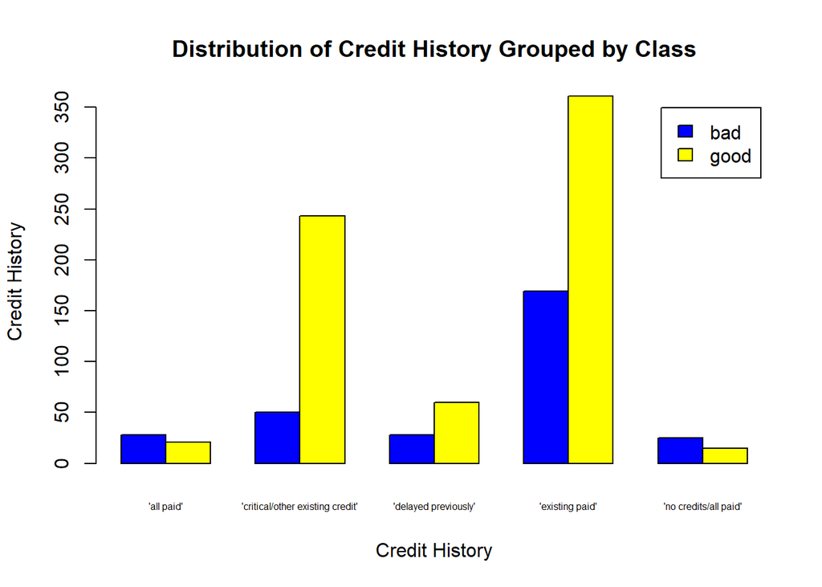

```r
cred_hist_by_class <- table(df$class, df$credit_history)
barplot(cred_hist_by_class,
        main="Distribution of Credit History Grouped by Class",
        xlab="Credit History",
        ylab="Credit History",
        col=c("blue","yellow"),
        cex.names = 0.5,
        legend = rownames(cred_hist_by_class), beside=TRUE)
```

An alternative way is to use ggplot2 package.

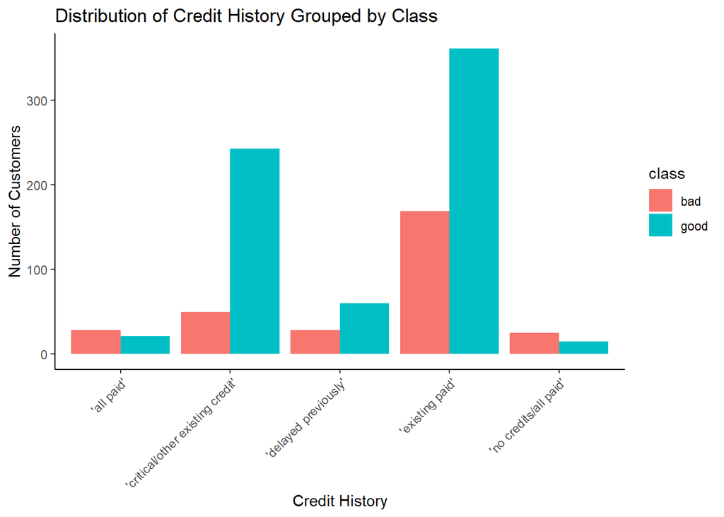

```r
# Load ggplot2 library
library(ggplot2)

ggplot(data = df, aes(x=credit_history, fill = class)) +
  theme_classic() +
  ggtitle("Distribution of Credit History Grouped by Class") +
  xlab("Credit History") +
  ylab("Number of Customers") +
  geom_bar(position="dodge") +
  theme(axis.text.x = element_text(angle = 45, hjust = 1))
```

From the plot, it seems that credit history variable is a good predictor to separate the two credit classes.

# 3. Boxplot

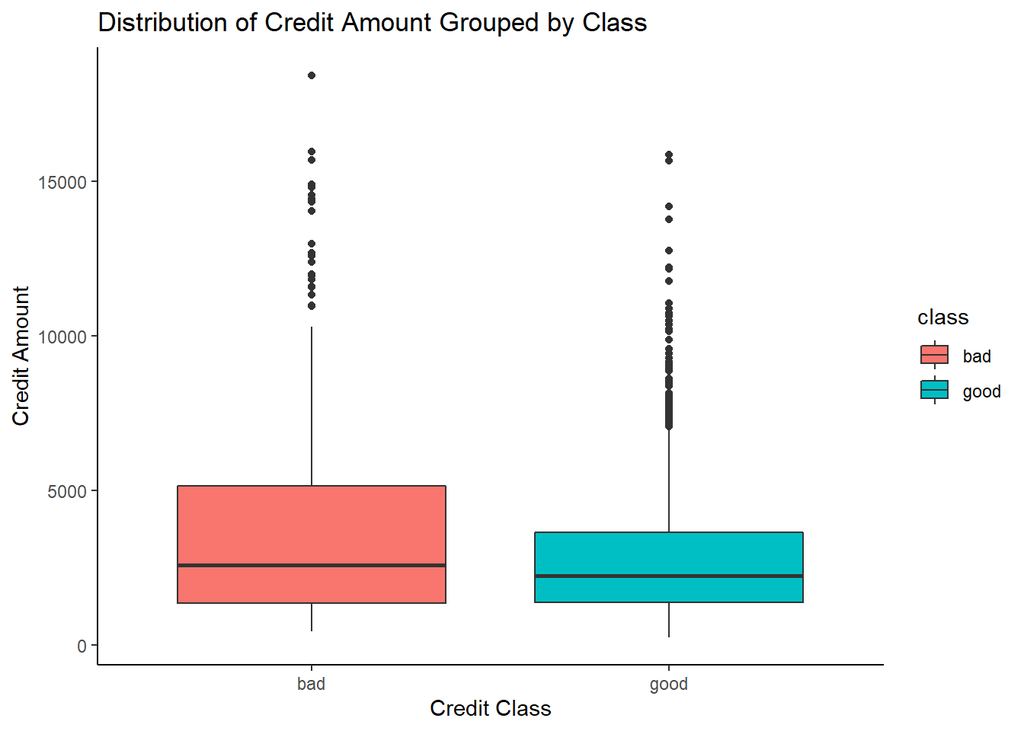

```r
ggplot(data=df, aes(x=class, y=credit_amount, fill = class)) +
  theme_classic() +
  geom_boxplot() +
  ggtitle("Distribution of Credit Amount Grouped by Class") +
  xlab("Credit Class") +
  ylab("Credit Amount")
```

From the above boxplot, we can see that bad credit customers tend to have larger credit amount.

# 4. Data Split

Randomly split the whole dataset as two parts: training set containing 80% of the data, and test set containing 20% of the data.

```r
# Data partition: randomly split the dataset into a train (80%) and a test set (20%)
index <- 1:nrow(df)
set.seed(123)
train_index <- sample(index, round(length(index)*0.8))
train_set <- df[train_index,]
test_set <- df[-train_index,]
```

# 5. Logistic Regression

Since our purpuse is to predict bad credit customers, let’s set the reference of the class as “good”. This makes sure that we are doing the modeling as:

$Logit(class=`bad'|X)=\beta_0 + \beta_1x_1+...+\beta_px_p$

```r
train_set$class <- relevel(train_set$class , ref = "good")
```

```r
# Train the logistic regression model
logit.fit.train <- glm(class ~.,
                       family=binomial(link='logit'),
                       data = train_set)

summary(logit.fit.train)
```

```
##
## Call:
## glm(formula = class ~ ., family = binomial(link = "logit"), data = train_set)
##
## Deviance Residuals:
##     Min       1Q   Median       3Q      Max
## -2.3832  -0.6979  -0.3736   0.6642   2.8197
##
## Coefficients:
##                                                  Estimate Std. Error z value
## (Intercept)                                    -3.875e+00  1.687e+00  -2.297
## checking_status<0                               1.672e+00  2.663e-01   6.280
## checking_status>=200                            9.336e-01  4.168e-01   2.240
## checking_status0<=X<200                         1.433e+00  2.668e-01   5.371
## duration                                        2.906e-02  1.025e-02   2.834
## credit_history'critical/other existing credit' -1.623e+00  4.939e-01  -3.287
## credit_history'delayed previously'             -1.063e+00  5.427e-01  -1.959
## credit_history'existing paid'                  -9.681e-01  4.313e-01  -2.245
## credit_history'no credits/all paid'            -2.618e-01  6.385e-01  -0.410
## purpose'new car'                               -2.690e-01  8.668e-01  -0.310
## purpose'used car'                              -2.005e+00  9.411e-01  -2.131
## purposebusiness                                -1.290e+00  9.195e-01  -1.403
## purposeeducation                               -5.252e-01  9.433e-01  -0.557
## purposefurniture/equipment                     -1.021e+00  8.724e-01  -1.171
## purposeother                                   -1.767e+00  1.263e+00  -1.399
## purposeradio/tv                                -1.114e+00  8.662e-01  -1.286
## purposerepairs                                 -2.057e-01  1.038e+00  -0.198
## purposeretraining                              -1.967e+00  1.593e+00  -1.235
## credit_amount                                   1.500e-04  4.945e-05   3.034
## savings_status<100                              1.045e+00  3.076e-01   3.398
## savings_status>=1000                           -2.110e-01  6.008e-01  -0.351
## savings_status100<=X<500                        5.429e-01  4.050e-01   1.341
## savings_status500<=X<1000                       3.449e-01  5.409e-01   0.638
## employment>=7                                  -3.949e-01  3.379e-01  -1.169
## employment1<=X<4                               -1.321e-01  2.733e-01  -0.484
## employment4<=X<7                               -8.868e-01  3.458e-01  -2.565
## employmentunemployed                           -2.311e-01  4.880e-01  -0.474
## installment_commitment                          3.834e-01  9.996e-02   3.836
## personal_status'male div/sep'                   3.040e-01  4.285e-01   0.709
## personal_status'male mar/wid'                   1.517e-01  3.418e-01   0.444
```

[output cut: 64 more lines]

```
## job'unskilled resident'                        0.608401
## jobskilled                                     0.405499
## num_dependents                                 0.057030 .
## own_telephoneyes                               0.188095
## foreign_workeryes                              0.067391 .
## ---
## Signif. codes:  0 '***' 0.001 '**' 0.01 '*' 0.05 '.' 0.1 ' ' 1
##
## (Dispersion parameter for binomial family taken to be 1)
##
##     Null deviance: 959.84  on 799  degrees of freedom
## Residual deviance: 705.09  on 751  degrees of freedom
## AIC: 803.09
##
## Number of Fisher Scoring iterations: 5
```

An alternative way to ensure that the positive class is “bad” is to specify the regression formula as:

class ==‘bad’ ~.

By specifying the response variable in this way, we don’t need to change the reference class.

```r
# Train the logistic regression model
logit.fit.train2 <- glm(class =='bad' ~.,
                       family=binomial(link='logit'),
                       data = train_set)

summary(logit.fit.train2)
```

```
##
## Call:
## glm(formula = class == "bad" ~ ., family = binomial(link = "logit"),
##     data = train_set)
##
## Deviance Residuals:
##     Min       1Q   Median       3Q      Max
## -2.3832  -0.6979  -0.3736   0.6642   2.8197
##
## Coefficients:
##                                                  Estimate Std. Error z value
## (Intercept)                                    -3.875e+00  1.687e+00  -2.297
## checking_status<0                               1.672e+00  2.663e-01   6.280
## checking_status>=200                            9.336e-01  4.168e-01   2.240
## checking_status0<=X<200                         1.433e+00  2.668e-01   5.371
## duration                                        2.906e-02  1.025e-02   2.834
## credit_history'critical/other existing credit' -1.623e+00  4.939e-01  -3.287
## credit_history'delayed previously'             -1.063e+00  5.427e-01  -1.959
## credit_history'existing paid'                  -9.681e-01  4.313e-01  -2.245
## credit_history'no credits/all paid'            -2.618e-01  6.385e-01  -0.410
## purpose'new car'                               -2.690e-01  8.668e-01  -0.310
## purpose'used car'                              -2.005e+00  9.411e-01  -2.131
## purposebusiness                                -1.290e+00  9.195e-01  -1.403
## purposeeducation                               -5.252e-01  9.433e-01  -0.557
## purposefurniture/equipment                     -1.021e+00  8.724e-01  -1.171
## purposeother                                   -1.767e+00  1.263e+00  -1.399
## purposeradio/tv                                -1.114e+00  8.662e-01  -1.286
## purposerepairs                                 -2.057e-01  1.038e+00  -0.198
## purposeretraining                              -1.967e+00  1.593e+00  -1.235
## credit_amount                                   1.500e-04  4.945e-05   3.034
## savings_status<100                              1.045e+00  3.076e-01   3.398
## savings_status>=1000                           -2.110e-01  6.008e-01  -0.351
## savings_status100<=X<500                        5.429e-01  4.050e-01   1.341
## savings_status500<=X<1000                       3.449e-01  5.409e-01   0.638
## employment>=7                                  -3.949e-01  3.379e-01  -1.169
## employment1<=X<4                               -1.321e-01  2.733e-01  -0.484
## employment4<=X<7                               -8.868e-01  3.458e-01  -2.565
## employmentunemployed                           -2.311e-01  4.880e-01  -0.474
## installment_commitment                          3.834e-01  9.996e-02   3.836
## personal_status'male div/sep'                   3.040e-01  4.285e-01   0.709
```

[output cut: 65 more lines]

```
## job'unskilled resident'                        0.608401
## jobskilled                                     0.405499
## num_dependents                                 0.057030 .
## own_telephoneyes                               0.188095
## foreign_workeryes                              0.067391 .
## ---
## Signif. codes:  0 '***' 0.001 '**' 0.01 '*' 0.05 '.' 0.1 ' ' 1
##
## (Dispersion parameter for binomial family taken to be 1)
##
##     Null deviance: 959.84  on 799  degrees of freedom
## Residual deviance: 705.09  on 751  degrees of freedom
## AIC: 803.09
##
## Number of Fisher Scoring iterations: 5
```

Let’s just show the coefficients with p-value < 0.05.

```r
coe <- coef(summary(logit.fit.train))

coe[coe[,4]<0.05,]
```

```
##                                                     Estimate   Std. Error
## (Intercept)                                    -3.8752165937 1.686902e+00
## checking_status<0                               1.6723358457 2.662981e-01
## checking_status>=200                            0.9335857585 4.167509e-01
## checking_status0<=X<200                         1.4331259006 2.668465e-01
## duration                                        0.0290587176 1.025390e-02
## credit_history'critical/other existing credit' -1.6234057531 4.939018e-01
## credit_history'existing paid'                  -0.9680597405 4.312922e-01
## purpose'used car'                              -2.0051098273 9.410979e-01
## credit_amount                                   0.0001500366 4.945487e-05
## savings_status<100                              1.0454312250 3.076221e-01
## employment4<=X<7                               -0.8867563401 3.457657e-01
## installment_commitment                          0.3833974348 9.995987e-02
## personal_status'male single'                   -0.6658183355 2.383702e-01
## other_partiesguarantor                         -1.4369258117 6.533947e-01
##                                                  z value     Pr(>|z|)
## (Intercept)                                    -2.297238 2.160519e-02
## checking_status<0                               6.279938 3.387079e-10
## checking_status>=200                            2.240153 2.508100e-02
## checking_status0<=X<200                         5.370601 7.847475e-08
## duration                                        2.833920 4.598087e-03
## credit_history'critical/other existing credit' -3.286900 1.012968e-03
## credit_history'existing paid'                  -2.244557 2.479660e-02
## purpose'used car'                              -2.130607 3.312152e-02
## credit_amount                                   3.033809 2.414876e-03
## savings_status<100                              3.398427 6.777445e-04
## employment4<=X<7                               -2.564617 1.032899e-02
## installment_commitment                          3.835514 1.253022e-04
## personal_status'male single'                   -2.793211 5.218765e-03
## other_partiesguarantor                         -2.199170 2.786586e-02
```

```r
# Calculate probability
test_probs <- predict(logit.fit.train, newdata = test_set, type="response")

# Calculate predicted class
test_pred <- ifelse(test_probs >.5, "bad", "good")

# Evaluate performance
library(caret)
confusionMatrix(factor(test_pred),test_set$class, positive = "bad")
```

```
## Confusion Matrix and Statistics
##
##           Reference
## Prediction bad good
##       bad   39   16
##       good  31  114
##
##                Accuracy : 0.765
##                  95% CI : (0.7, 0.8219)
##     No Information Rate : 0.65
##     P-Value [Acc > NIR] : 0.0002983
##
##                   Kappa : 0.4566
##
##  Mcnemar's Test P-Value : 0.0411406
##
##             Sensitivity : 0.5571
##             Specificity : 0.8769
##          Pos Pred Value : 0.7091
##          Neg Pred Value : 0.7862
##              Prevalence : 0.3500
##          Detection Rate : 0.1950
##    Detection Prevalence : 0.2750
##       Balanced Accuracy : 0.7170
##
##        'Positive' Class : bad
##
```

As our purpose is to detect bad credit customers, sensitivity is a good measure to use.

Sensitivity = 0.5571. That is to say, only 55.71% of bad credit customers have been correctly predicted as bad credit customers. The logistic regression does not perform well in classifying bad credit customers.

# 6. LDA

Perform LDA on the training data in order to predict class using other variables.

```r
library(MASS)
```

```r
lda.fit <- lda(class ~ checking_status + duration + credit_history +
               credit_amount + savings_status + employment +
               installment_commitment + personal_status +
               other_parties + other_payment_plans,
               data = train_set)
lda.fit
```

```
## Call:
## lda(class ~ checking_status + duration + credit_history + credit_amount +
##     savings_status + employment + installment_commitment + personal_status +
##     other_parties + other_payment_plans, data = train_set)
##
## Prior probabilities of groups:
##   good    bad
## 0.7125 0.2875
##
## Group means:
##      checking_status<0 checking_status>=200 checking_status0<=X<200 duration
## good         0.2000000           0.07017544               0.2438596 19.18421
## bad          0.4478261           0.05652174               0.3434783 24.58696
##      credit_history'critical/other existing credit'
## good                                      0.3473684
## bad                                       0.1782609
##      credit_history'delayed previously' credit_history'existing paid'
## good                         0.07543860                     0.5280702
## bad                          0.08695652                     0.5608696
##      credit_history'no credits/all paid' credit_amount savings_status<100
## good                          0.01929825      3010.340          0.5561404
## bad                           0.07391304      3894.574          0.7391304
##      savings_status>=1000 savings_status100<=X<500 savings_status500<=X<1000
## good           0.05789474                0.1017544                0.07719298
## bad            0.02608696                0.1086957                0.03043478
##      employment>=7 employment1<=X<4 employment4<=X<7 employmentunemployed
## good     0.2649123        0.3350877        0.2000000           0.05964912
## bad      0.2043478        0.3565217        0.1304348           0.07391304
##      installment_commitment personal_status'male div/sep'
## good               2.905263                    0.04210526
## bad                3.104348                    0.07391304
##      personal_status'male mar/wid' personal_status'male single'
## good                    0.08947368                    0.5754386
## bad                     0.10000000                    0.4652174
##      other_partiesguarantor other_partiesnone other_payment_plansnone
## good             0.06140351         0.9070175               0.8263158
## bad              0.03478261         0.9130435               0.7608696
##      other_payment_plansstores
## good                0.04385965
## bad                 0.05217391
```

[output cut: 13 more lines]

```
## savings_status>=1000                           -0.0819519205
## savings_status100<=X<500                        0.4845079907
## savings_status500<=X<1000                       0.1324189879
## employment>=7                                  -0.4418165552
## employment1<=X<4                               -0.2157045090
## employment4<=X<7                               -0.7543329980
## employmentunemployed                           -0.3921901538
## installment_commitment                          0.2691170069
## personal_status'male div/sep'                   0.1731573092
## personal_status'male mar/wid'                  -0.0847392757
## personal_status'male single'                   -0.4805367280
## other_partiesguarantor                         -1.3892006356
## other_partiesnone                              -0.3218175930
## other_payment_plansnone                        -0.2460650345
## other_payment_plansstores                      -0.4189308087
```

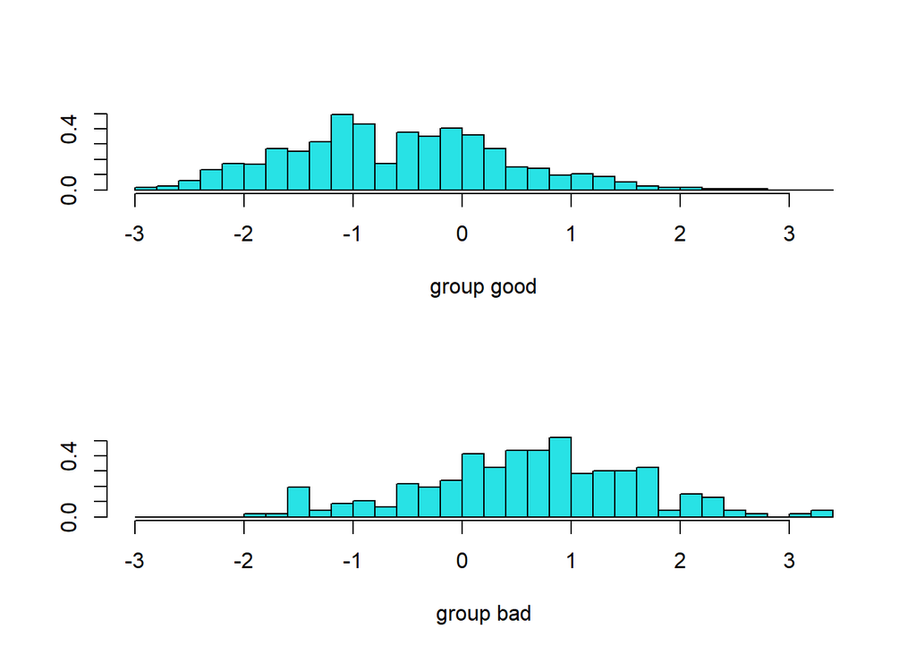

```r
plot(lda.fit)
```

Evaluate the performance of LDA on test set.

```r
lda.pred <- predict(lda.fit,test_set)

confusionMatrix(lda.pred$class, test_set$class, positive = "bad")
```

```
## Confusion Matrix and Statistics
##
##           Reference
## Prediction bad good
##       bad   34   13
##       good  36  117
##
##                Accuracy : 0.755
##                  95% CI : (0.6894, 0.8129)
##     No Information Rate : 0.65
##     P-Value [Acc > NIR] : 0.0009148
##
##                   Kappa : 0.4174
##
##  Mcnemar's Test P-Value : 0.0016731
##
##             Sensitivity : 0.4857
##             Specificity : 0.9000
##          Pos Pred Value : 0.7234
##          Neg Pred Value : 0.7647
##              Prevalence : 0.3500
##          Detection Rate : 0.1700
##    Detection Prevalence : 0.2350
##       Balanced Accuracy : 0.6929
##
##        'Positive' Class : bad
##
```

Sensitivity = 0.4857. That is to say, only 48.57% of bad credit customers have been correctly predicted as bad credit customers. The LDA does not perform well in classifying bad credit customers, even worse than logistic regression model.

# 7. QDA

Perform LDA on the training data in order to predict class using other variables.

```r
qda.fit <- qda(class ~ checking_status + duration + credit_history +
               credit_amount + savings_status + employment +
               installment_commitment + personal_status +
               other_parties + other_payment_plans,
               data = train_set)
qda.fit
```

```
## Call:
## qda(class ~ checking_status + duration + credit_history + credit_amount +
##     savings_status + employment + installment_commitment + personal_status +
##     other_parties + other_payment_plans, data = train_set)
##
## Prior probabilities of groups:
##   good    bad
## 0.7125 0.2875
##
## Group means:
##      checking_status<0 checking_status>=200 checking_status0<=X<200 duration
## good         0.2000000           0.07017544               0.2438596 19.18421
## bad          0.4478261           0.05652174               0.3434783 24.58696
##      credit_history'critical/other existing credit'
## good                                      0.3473684
## bad                                       0.1782609
##      credit_history'delayed previously' credit_history'existing paid'
## good                         0.07543860                     0.5280702
## bad                          0.08695652                     0.5608696
##      credit_history'no credits/all paid' credit_amount savings_status<100
## good                          0.01929825      3010.340          0.5561404
## bad                           0.07391304      3894.574          0.7391304
##      savings_status>=1000 savings_status100<=X<500 savings_status500<=X<1000
## good           0.05789474                0.1017544                0.07719298
## bad            0.02608696                0.1086957                0.03043478
##      employment>=7 employment1<=X<4 employment4<=X<7 employmentunemployed
## good     0.2649123        0.3350877        0.2000000           0.05964912
## bad      0.2043478        0.3565217        0.1304348           0.07391304
##      installment_commitment personal_status'male div/sep'
## good               2.905263                    0.04210526
## bad                3.104348                    0.07391304
##      personal_status'male mar/wid' personal_status'male single'
## good                    0.08947368                    0.5754386
## bad                     0.10000000                    0.4652174
##      other_partiesguarantor other_partiesnone other_payment_plansnone
## good             0.06140351         0.9070175               0.8263158
## bad              0.03478261         0.9130435               0.7608696
##      other_payment_plansstores
## good                0.04385965
## bad                 0.05217391
```

Evaluate the performance of QDA on test set.

```r
qda.pred <- predict(qda.fit,test_set)

confusionMatrix(qda.pred$class, test_set$class, positive = "bad")
```

```
## Confusion Matrix and Statistics
##
##           Reference
## Prediction bad good
##       bad   43   24
##       good  27  106
##
##                Accuracy : 0.745
##                  95% CI : (0.6787, 0.8039)
##     No Information Rate : 0.65
##     P-Value [Acc > NIR] : 0.002535
##
##                   Kappa : 0.434
##
##  Mcnemar's Test P-Value : 0.779435
##
##             Sensitivity : 0.6143
##             Specificity : 0.8154
##          Pos Pred Value : 0.6418
##          Neg Pred Value : 0.7970
##              Prevalence : 0.3500
##          Detection Rate : 0.2150
##    Detection Prevalence : 0.3350
##       Balanced Accuracy : 0.7148
##
##        'Positive' Class : bad
##
```

Sensitivity = 0.6143. That is to say, 61.43% of bad credit customers have been correctly predicted as bad credit customers. The QDA does a decent job in classifying bad credit customers.

# 8. Comparison

Among the three models, we can find that QDA has the best sensitivity. So QDA performs best for predicting bad credit customers.